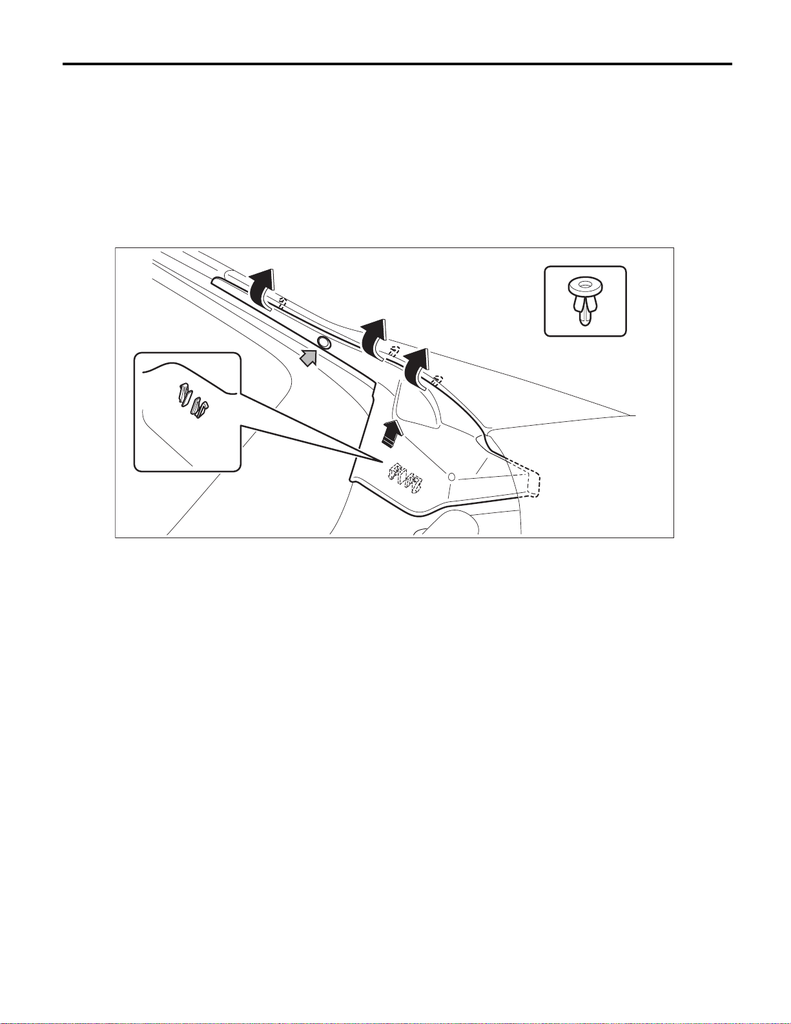

Cowl Panel

EXTERIOR/INTERIOR TRIM

10.Cowl Panel

A: REMOVAL

1) Remove the arm assembly - windshield wiper. <Ref. to WW-19, REMOVAL, Front Wiper Arm.>

2) Remove the cowl panel - side.

(1) Remove the clips.

(2) Release the claws, and then remove the cowl panel - side.

CAUTION:

Pulling with excessive force may damage the cowl panel - side. If it is difficult to remove, use a plastic

remover or equivalent tool.

3) Remove the cowl panel assembly.

CAUTION:

Before removing the cowl panel, use an air blower and nylon brush to sweep gravel from the lower

area of the front side of the glass.

(1) Disconnect the washer hose.

(2) Remove clips (A).

(3) Check the direction of the clip (B), and push the claws from both sides to remove it.

CAUTION:

When removing the clip (B), push the claws of the clip first.

Be careful not to apply excessive force when pulling the clip (B), as the clip may become damaged.

WW-00824

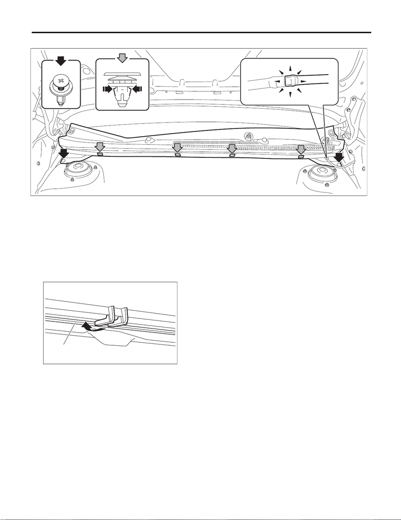

Cowl Panel

EXTERIOR/INTERIOR TRIM

(4) Remove the cowl panel assembly by pulling it out towards the front of the vehicle.

B: INSTALLATION

CAUTION:

Before installing the windshield glass and cowl panel, make sure there are no gravel in the installing

area.

1) Install the cowl panel assembly.

CAUTION:

If the cowl panel assembly cannot be installed properly, do not hit or set it forcibly. The claws of the

cowl panel or the windshield glass may be damaged.

(1) Hook the claw of the cowl panel on the lower end (1) of the windshield.

EI-03698

(A)

(B)

EI-00888

(1)

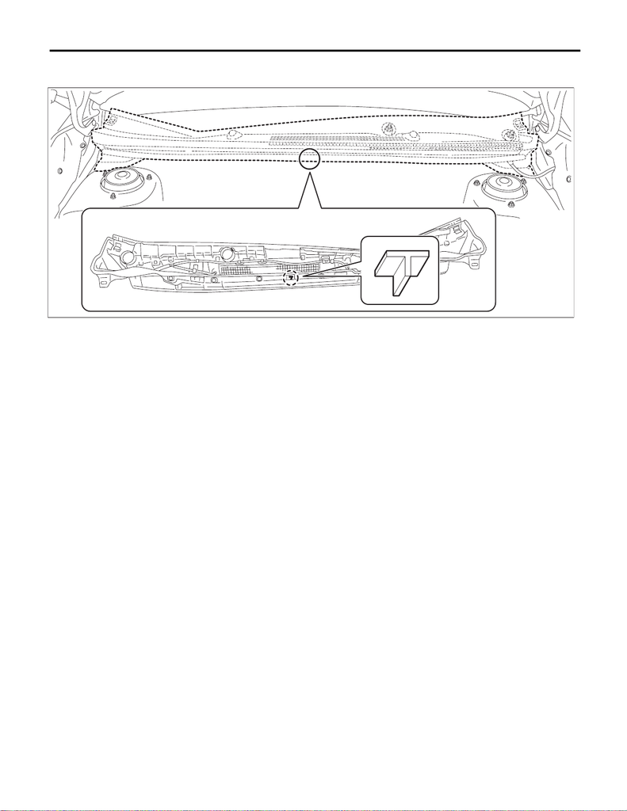

Cowl Panel

EXTERIOR/INTERIOR TRIM

(2) Align the center claw of the cowl panel assembly to the cutout portion of the vehicle side, then install

the cowl panel assembly.

2) Install the cowl panel - side.

3) Install the arm assembly - windshield wiper. <Ref. to WW-19, INSTALLATION, Front Wiper Arm.>

4) If the washer nozzles have been removed from the cowl panel assembly, adjust the washer spray posi-

tions. <Ref. to WW-27, ADJUSTMENT, Front Washer Nozzle.>

EI-03566